# Testing squarem update in maptpx

Kushal K Dey

April 20, 2016

## Overview

In this script, we check how fast we can make the topic model algorithm if we get rid of the active set update. Here we shall consider both scenarios. On a simulated data, we will apply the topic model maptpx algorithm with the active set update and the topic model without the active set update and then check which method converges faster and what is the total time taken to reach convergence for either of the two methods. We would also like to figure out how many iterations are required by either of these methods before convergence is reached.

## Simulation Design

```r
n.out <- 400
omega_sim <- rbind( cbind( rep(1, n.out), rep(0, n.out)),
                    cbind( rep(0, n.out), rep(1, n.out)),
                    cbind( seq(0.6, 0.4, length.out = n.out),
                           1- seq(0.6, 0.4,length.out=n.out)) )
dim(omega_sim)
```

```
## [1] 1200    2
```

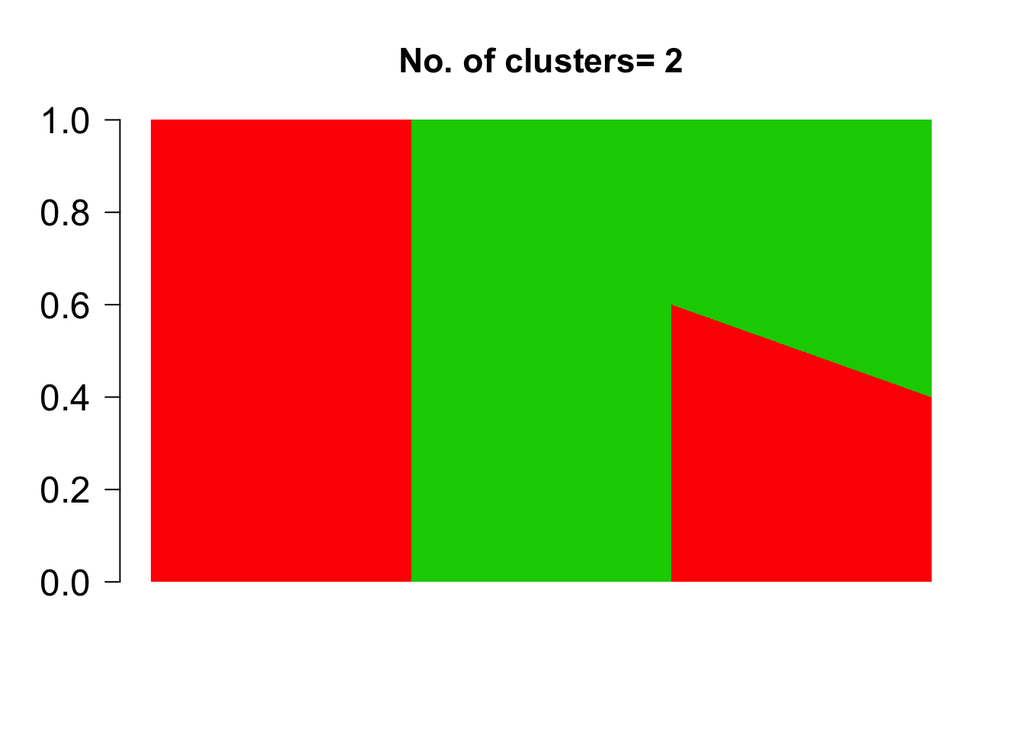

```r
K <- dim(omega_sim)[2]
barplot(t(omega_sim),
        col = 2:(K+1),
        axisnames = F, space = 0,
        border = NA,
        main=paste("No. of clusters=", K),
        las=1, ylim = c(0,1), cex.axis=1.5,cex.main=1.4)
```

$\begin{pmatrix} q_{,11} & q_{1,2} & \dots & q_{1,G} \\ q_{2,1} & q_{2,2} & \dots & q_{2,G} \end{pmatrix}$

```r
freq <- rbind( c(0.1, 0.2, rep(0.70/998, 998)),
               c(rep(0.70/998,998), 0.1, 0.2) )
str(freq)
```

```
##  num [1:2, 1:1000] 0.1 0.000701 0.2 0.000701 0.000701 ...
```

Now we generate the counts table given the topic proportions matrix and the topic distributions.

For every cell $n$, we assume that $C_{n.}$ the vector of read counts coming from genes 1 to G follows a multinomial distribution where $\left( p_{n,1}, \dots, p_{n,G} \right)$ the probabilities of a read coming from genes 1 to $G$ sum up to 1. That is,

$C_{n.} \sim Multinomial \left( C_{n+}, p_{n.} \right)$

and

$p_{n.}= \sum_{k=1}^{K} q_{nk} \theta_{kg}$.

```r
counts <- t( do.call(cbind,
                     lapply(1:dim(omega_sim)[1],
                            function(x)
                                rmultinom(1,1000,prob=omega_sim[x,]%*%freq))))
dim(counts)
```

```
## [1] 1200 1000
```

## maptpx

```r
library(slam)
library(maptpx)
source("../../../maptpx/R/topics.R")
source("../../../maptpx/R/tpx.R")
source("../../../maptpx/R/count.R")
```

### active set (each iteration)

```r
system.time(Topic_clus <- topics(counts, K=2, tol=0.001, method_admix=1,
                                 nbundles=1));
```

```
##
## Estimating on a 1200 document collection.
## Fitting the 2 topic model.
## log posterior increase: 755684.758, 27.862, 9.151, 8.985, 3.798, 0.167, 0.041, 0.013, 0.005, 0.002, done.
```

```
##    user  system elapsed
##  10.974   2.365  14.273
```

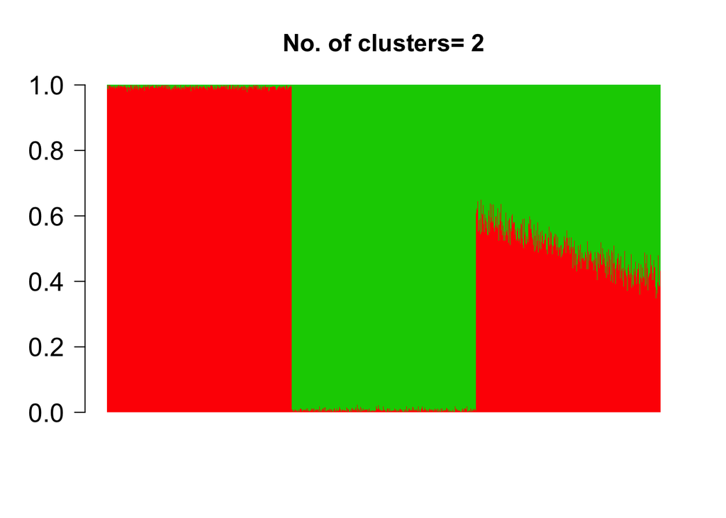

```r
# These are estimated gene relative expression
docweights <- Topic_clus$omega

library(permute)
library(BioPhysConnectoR)

# Decide on the correspondance of the simulated
# and of the estimated relative expression matrix
#
# We consider all possible cluster ordering in the
# estimated relative expression matrix and select
# the relative expression matrix with the nearest
# distance to the simulate relative experssion matrix
# (forbieus norm)

perm_set <- rbind(1:K,allPerms(1:K))
diff <- array(0,dim(perm_set)[1])
for (p in 1:dim(perm_set)[1])
{
    temp <- docweights[, perm_set[p,]]
    diff[p] <- fnorm(temp,omega_sim)
}

p_star <- which(diff==min(diff))
docweights <- docweights[,perm_set[p_star,]]

barplot(t(docweights),
        col = 2:(K+1),
        axisnames = F, space = 0, border = NA,
        main=paste("No. of clusters=", K),
        las=1, ylim=c(0,1), cex.axis=1.5, cex.main=1.4)
```

### active set update (every 2 iterations)

```r
system.time(Topic_clus <- topics(counts, K=2, tol=0.001, method_admix=1,
                                 nbundles=2));
```

```
##
## Estimating on a 1200 document collection.
## Fitting the 2 topic model.
## log posterior increase: 755684.758, 159.213, 113.793, done.
```

```
##    user  system elapsed
##   3.218   0.585   5.204
```

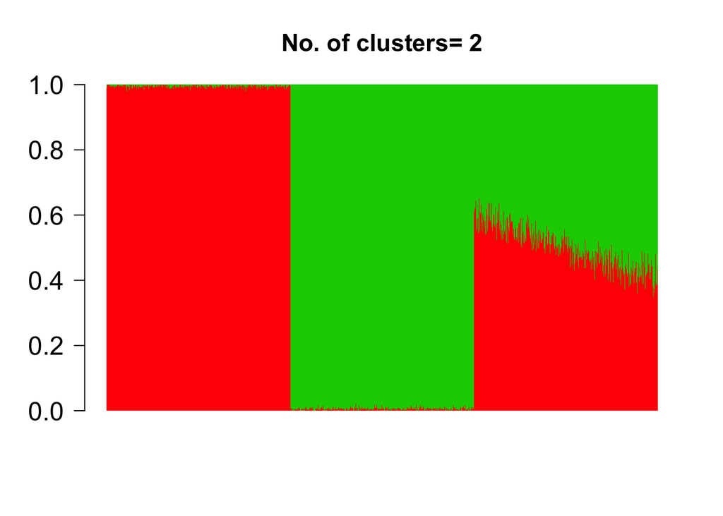

```r
# These are estimated gene relative expression
docweights <- Topic_clus$omega

library(permute)
library(BioPhysConnectoR)

# Decide on the correspondance of the simulated
# and of the estimated relative expression matrix
#
# We consider all possible cluster ordering in the
# estimated relative expression matrix and select
# the relative expression matrix with the nearest
# distance to the simulate relative experssion matrix
# (forbieus norm)

perm_set <- rbind(1:K,allPerms(1:K))
diff <- array(0,dim(perm_set)[1])
for (p in 1:dim(perm_set)[1])
{
    temp <- docweights[, perm_set[p,]]
    diff[p] <- fnorm(temp,omega_sim)
}

p_star <- which(diff==min(diff))
docweights <- docweights[,perm_set[p_star,]]

barplot(t(docweights),
        col = 2:(K+1),
        axisnames = F, space = 0, border = NA,
        main=paste("No. of clusters=", K),
        las=1, ylim=c(0,1), cex.axis=1.5, cex.main=1.4)
```

### active set update (every 5 iterations)

```r
system.time(Topic_clus <- topics(counts, K=2, tol=0.001, method_admix=1,
                                 nbundles=5));
```

```
##
## Estimating on a 1200 document collection.
## Fitting the 2 topic model.
## log posterior increase: 681788.035, 1204.323, 39.386, done.
```

```
##    user  system elapsed
##   2.843   0.604   4.250
```

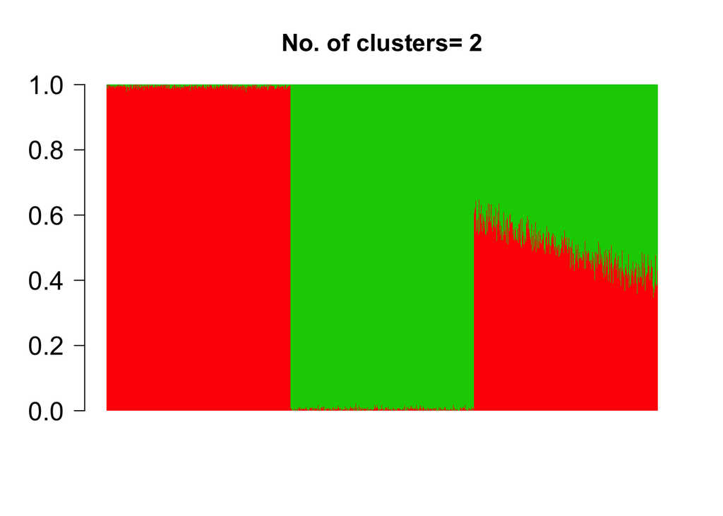

```r
# These are estimated gene relative expression
docweights <- Topic_clus$omega

library(permute)
library(BioPhysConnectoR)

# Decide on the correspondance of the simulated
# and of the estimated relative expression matrix
#
# We consider all possible cluster ordering in the
# estimated relative expression matrix and select
# the relative expression matrix with the nearest
# distance to the simulate relative experssion matrix
# (forbieus norm)

perm_set <- rbind(1:K,allPerms(1:K))
diff <- array(0,dim(perm_set)[1])
for (p in 1:dim(perm_set)[1])
{
    temp <- docweights[, perm_set[p,]]
    diff[p] <- fnorm(temp,omega_sim)
}

p_star <- which(diff==min(diff))
docweights <- docweights[,perm_set[p_star,]]

barplot(t(docweights),
        col = 2:(K+1),
        axisnames = F, space = 0, border = NA,
        main=paste("No. of clusters=", K),
        las=1, ylim=c(0,1), cex.axis=1.5, cex.main=1.4)
```

### active set update (every 10000 iterations: essentially no update)

```r
system.time(Topic_clus <- topics(counts, K=2, tol=0.001, method_admix=1,
                                 nbundles=10000));
```

```
##
## Estimating on a 1200 document collection.
## Fitting the 2 topic model.
## log posterior increase: 681788.035, 25.179, done.
```

```
##    user  system elapsed
##   2.231   0.466   2.779
```

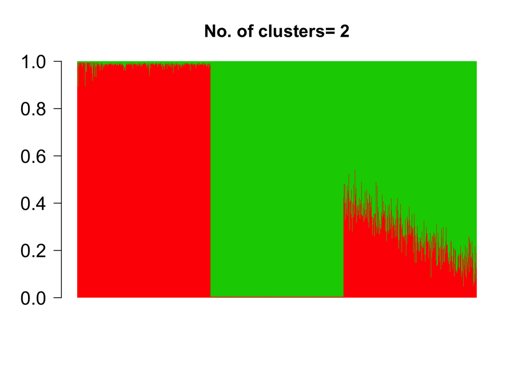

```r
# These are estimated gene relative expression
docweights <- Topic_clus$omega

library(permute)
library(BioPhysConnectoR)

# Decide on the correspondance of the simulated
# and of the estimated relative expression matrix
#
# We consider all possible cluster ordering in the
# estimated relative expression matrix and select
# the relative expression matrix with the nearest
# distance to the simulate relative experssion matrix
# (forbieus norm)

perm_set <- rbind(1:K,allPerms(1:K))
diff <- array(0,dim(perm_set)[1])
for (p in 1:dim(perm_set)[1])
{
    temp <- docweights[, perm_set[p,]]
    diff[p] <- fnorm(temp,omega_sim)
}

p_star <- which(diff==min(diff))
docweights <- docweights[,perm_set[p_star,]]

barplot(t(docweights),
        col = 2:(K+1),
        axisnames = F, space = 0, border = NA,
        main=paste("No. of clusters=", K),
        las=1, ylim=c(0,1), cex.axis=1.5, cex.main=1.4)
```